# A Classifier for Human Activity Recognition

09/16/2014

## Human Activity Recognition

One thing that people regularly do is quantify how much of a particular activity they do, but they rarely quantify how well they do it.

The availability of devices such as Jawbone Up, Nike FuelBand, and Fitbit make now possible to collect a large amount of data about personal activity at relatively low costs.

[figure not shown]

## Dataset

In this project I use Wearable Accelerometers’ Data from the dataset provided at http://groupware.les.inf.puc-rio.br/har

Description: six young health participants were asked to perform one set of 10 repetitions of the Unilateral Dumbbell Biceps Curl in 5 different fashions:

- exactly according to the specification (Class A)
- throwing the elbows to the front (Class B)
- lifting the dumbbell only halfway (Class C)
- lowering the dumbbell only halfway (Class D)
- throwing the hips to the front (Class E)

## Train data

Train data have 160 variables and 19622 measurements. Each measurements contains the participant name, time stamp information, a set of measurement from accelerometers, and the the 'Class' variable.

The objective is to predict the class variables, given a set of measurements, on an independent test set.

## Train data

Samples from the dataset: The variable named *classe* contains labels for the exercise quality execution, the variable *user_name* the identifiers for the subject performing the exercise:

```r
unique(train$classe)
```

```
## [1] "A" "B" "C" "D" "E"
```

```r
unique(train$user_name)
```

```
## [1] "carlitos" "pedro"    "adelmo"   "charles"  "eurico"   "jeremy"
```

## Data cleaning

Some data variables seem to contain majority of NA values, empty strings “” or “#DIV/0!” values. Data variables representing averages, standard deviation, max, min operation will be removed.

In the following are listed the employed steps of data cleaning:

First bind train and test set.

```r
train$setType <- 'train'
test$setType <- 'test'
names(test)[160] <- 'classe'
alldata <- rbind(train, test)
```

Looking for missing values. Identify columns of NA values:

```r
res_na <- colSums( is.na(alldata) )
```

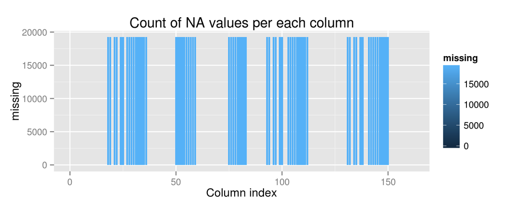

Remove the columns with almost all NA values.

```r
alldata <- alldata[,res_na < 5000]
sum(colSums(is.na(alldata)) )   # a few values NA remains
```

```
## [1] 660
```

Looking for missing values, in the form of empty string

```r
res_na <- colSums( alldata == '', na.rm=T )
```

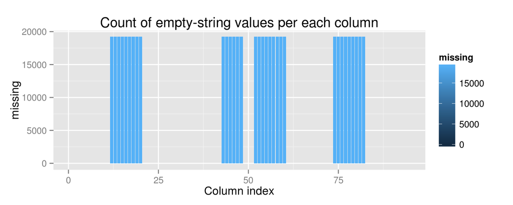

Remove columns with almost all "" values.

```r
alldata <- alldata[,res_na < 5000]
```

## Quick check

```r
# Count occurrence of "". Have been all removed?
sum(colSums( alldata=='', na.rm=T )) == 0
```

```
## [1] TRUE
```

```r
# Count occurrence of "#DIV/0!". Have been all removed?
sum( colSums( alldata=='#DIV/0!', na.rm=T)) == 0
```

```
## [1] TRUE
```

```r
# Count the occurrence of NA values. Have been all removed?
sum( colSums( is.na(alldata)) ) == 0
```

```
## [1] TRUE
```

```r
selected_label <- sapply( names(alldata), function(x) gregexpr(pattern ='^(avg_|stddev_|min_|max_)', x)[[1]][1] > 0 )
names(alldata)[selected_label]
```

```
## character(0)
```

Rename fist column

```r
names(alldata)[1]  <- 'counter'
```

## Split data in training and testing set

```r
training <- alldata[alldata$setType=='train',]
testing <- alldata[alldata$setType=='test',]
```

```r
nrow(training)
```

```
## [1] 19622
```

```r
nrow(testing)
```

```
## [1] 20
```

## Codebook summary table

```r
kable(codebook_df, format="markdown")
```

| varNames | description | values |
| --- | --- | --- |
| counter | a progressive counter of rows | 1 2 3 4 …. |
| user_name | the name of the subject making exrcise | {pedro, jeremy, adelmo, eurico, carlitos, charles} |
| raw_timestamp_part_1 | timestamp, part 1 (not specified) |  |
| raw_timestamp_part_2 | timestamp, part 2 (not specified) |  |
| cvtd_timestamp | a string representing date and time |  |
| roll_belt | a measurement |  |
| pitch_belt | a measurement |  |
| yaw_belt | a measurement |  |
| total_accel_belt | a measurement |  |
| gyros_belt_x | a measurement |  |
| gyros_belt_y | a measurement |  |
| gyros_belt_z | a measurement |  |
| accel_belt_x | a measurement |  |
| accel_belt_y | a measurement |  |
| accel_belt_z | a measurement |  |
| magnet_belt_x | a measurement |  |
| magnet_belt_y | a measurement |  |
| magnet_belt_z | a measurement |  |
| roll_arm | a measurement |  |
| pitch_arm | a measurement |  |
| yaw_arm | a measurement |  |
| total_accel_arm | a measurement |  |
| gyros_arm_x | a measurement |  |
| gyros_arm_y | a measurement |  |
| gyros_arm_z | a measurement |  |
| accel_arm_x | a measurement |  |
| accel_arm_y | a measurement |  |
| accel_arm_z | a measurement |  |
| magnet_arm_x | a measurement |  |
| magnet_arm_y | a measurement |  |
| magnet_arm_z | a measurement |  |
| roll_dumbbell | a measurement |  |
| pitch_dumbbell | a measurement |  |
| yaw_dumbbell | a measurement |  |
| total_accel_dumbbell | a measurement |  |
| gyros_dumbbell_x | a measurement |  |
| gyros_dumbbell_y | a measurement |  |
| gyros_dumbbell_z | a measurement |  |
| accel_dumbbell_x | a measurement |  |
| accel_dumbbell_y | a measurement |  |
| accel_dumbbell_z | a measurement |  |
| magnet_dumbbell_x | a measurement |  |
| magnet_dumbbell_y | a measurement |  |
| magnet_dumbbell_z | a measurement |  |
| roll_forearm | a measurement |  |
| pitch_forearm | a measurement |  |
| yaw_forearm | a measurement |  |
| total_accel_forearm | a measurement |  |
| gyros_forearm_x | a measurement |  |
| gyros_forearm_y | a measurement |  |
| gyros_forearm_z | a measurement |  |
| accel_forearm_x | a measurement |  |
| accel_forearm_y | a measurement |  |
| accel_forearm_z | a measurement |  |
| magnet_forearm_x | a measurement |  |
| magnet_forearm_y | a measurement |  |
| magnet_forearm_z | a measurement |  |
| classe | the 5 different fashions of making the excercise. A: correct execution according to the specification, {B,C,D,E} are incorrect variations | {A,B,C,D,E} |

## Building models

As I'm interested in a classification model, make *'classe'* a factor variable:

```r
training$classe <- as.factor( training$classe )
```

For reproducibility purpose set seed to 313:

```r
set.seed(313)
```

## Out-of-Sample error estimate

I split the data in two sets: a **training-set** and **trainTest-set** in respectively 80% and 20%. The trainTest-set is only used to make an *unbiased estimate of the out-of-sample error*.

I used the **k-fold cross validation** technique on the training-set to perform model selection. To keep computation time small, I chose values of K=3 and repeats=1.

Using the functionality of the caret package, I defined a trainControl parameter as:

```r
fitControl <- trainControl(method="repeatedcv", number=3, repeats=1 )
```

NOTE: I did not make feature selection. I used all the available variables (after the data cleaning as in previous section) as predictive variables.

Variables from 1 to 5 (the "counter", "user_name", "raw_timestamp_part_1", "raw_timestamp_part_2", "cvtd_timestamp") are discarded:

```r
dim_train = nrow(training)
id_trainTest <- sample(dim_train, dim_train*0.2,   replace = FALSE )

trainTest  <- training[id_trainTest,6:58]    # to extimate error
training2  <- training[-id_trainTest,6:58]   # train and cross-validation
testing    <- testing[,6:58]
```

## Build a Gradient Boosted Model

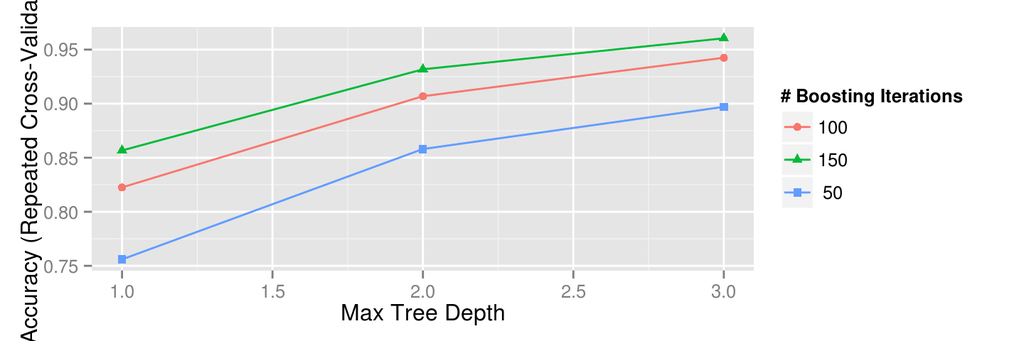

```r
fit_gbm <- train(classe~., method="gbm", data=training2,
                 trControl=fitControl, verbose=FALSE)
ggplot(fit_gbm)
```

The model parameter were chosen by cross validation. The final values are n.trees = 150, interaction.depth = 3 and shrinkage = 0.1

## In-Sample Accuracy

The error on the training-set is computed as:

```r
pred_gbm  <-  predict(fit_gbm, training2[-53] )
confusionMatrix(pred_gbm, training2$classe)
```

```
## Confusion Matrix and Statistics
##
##           Reference
## Prediction    A    B    C    D    E
##          A 4404   65    0    2    3
##          B   29 2960   69    5   11
##          C   10   54 2627   69   18
##          D    1    1   34 2461   31
##          E    1    0    6   13 2824
##
## Overall Statistics
##
##                Accuracy : 0.973
##                  95% CI : (0.97, 0.976)
##     No Information Rate : 0.283
##     P-Value [Acc > NIR] : < 2e-16
##
##                   Kappa : 0.966
##  Mcnemar's Test P-Value : 2.76e-10
##
## Statistics by Class:
##
##                      Class: A Class: B Class: C Class: D Class: E
## Sensitivity             0.991    0.961    0.960    0.965    0.978
## Specificity             0.994    0.991    0.988    0.995    0.998
## Pos Pred Value          0.984    0.963    0.946    0.973    0.993
## Neg Pred Value          0.996    0.990    0.992    0.993    0.995
## Prevalence              0.283    0.196    0.174    0.162    0.184
## Detection Rate          0.281    0.189    0.167    0.157    0.180
## Detection Prevalence    0.285    0.196    0.177    0.161    0.181
## Balanced Accuracy       0.992    0.976    0.974    0.980    0.988
```

## Out-of-Sample Accuracy:

The generalization error on the new data is computed as: (NOTE: the trainTest-set is never used in training the ML model)

```r
pred_gbm  <-  predict(fit_gbm, trainTest[-53] )
confusionMatrix(pred_gbm, trainTest$classe)
```

```
## Confusion Matrix and Statistics
##
##           Reference
## Prediction    A    B    C    D    E
##          A 1114   18    0    0    1
##          B   11  682   30    3   11
##          C    6   15  644   30    6
##          D    1    1    8  624   10
##          E    3    1    4    9  692
##
## Overall Statistics
##
##                Accuracy : 0.957
##                  95% CI : (0.95, 0.963)
##     No Information Rate : 0.289
##     P-Value [Acc > NIR] : < 2e-16
##
##                   Kappa : 0.946
##  Mcnemar's Test P-Value : 5.2e-05
##
## Statistics by Class:
##
##                      Class: A Class: B Class: C Class: D Class: E
## Sensitivity             0.981    0.951    0.939    0.937    0.961
## Specificity             0.993    0.983    0.982    0.994    0.995
## Pos Pred Value          0.983    0.925    0.919    0.969    0.976
## Neg Pred Value          0.992    0.989    0.987    0.987    0.991
## Prevalence              0.289    0.183    0.175    0.170    0.183
## Detection Rate          0.284    0.174    0.164    0.159    0.176
## Detection Prevalence    0.289    0.188    0.179    0.164    0.181
## Balanced Accuracy       0.987    0.967    0.961    0.965    0.978
```

## Prediction on the Test-set

Outcomes prediction are computed as follows

```r
pred_testing_gbm <- predict(fit_gbm, testing[-53] )
print(pred_testing_gbm)
```

```
##  [1] B A B A A E D B A A B C B A E E A B B B
## Levels: A B C D E
```

## Conclusion

Human Activity Recognition and activity quality assessment are active research areas with application in safety, health prevention and wellness. This experiment shows that Machine learning technique and Wearable Accelerometers' data can be effectively used to make reliable assessments of activity quality.

Cite:

- Ugulino, W., Cardador, D., Vega, K., Velloso, E., Milidiú, R., & Fuks, H. (2012). Wearable computing: accelerometers’ data classification of body postures and movements. In Advances in Artificial Intelligence-SBIA 2012 (pp. 52-61). Springer Berlin Heidelberg.